# Final Project Draft

Tim Mastny

April 17, 2018

# Credit Card Defaults

This project will study credit card defaults. This report, the data, and all the code can be found at this project’s [Github repo](https://github.com/tmastny/ml-default). The following study was conducted on the [dataset](https://archive.ics.uci.edu/ml/datasets/default+of+credit+card+clients):

> Yeh, I. C., & Lien, C. H. (2009). The comparisons of data mining techniques for the predictive accuracy of probability of default of credit card clients. Expert Systems with Applications, 36(2), 2473-2480

The study found the following error rates based on a validation set. My goal is to see if we can replicate and improve on these results using modern machine learning techniques.

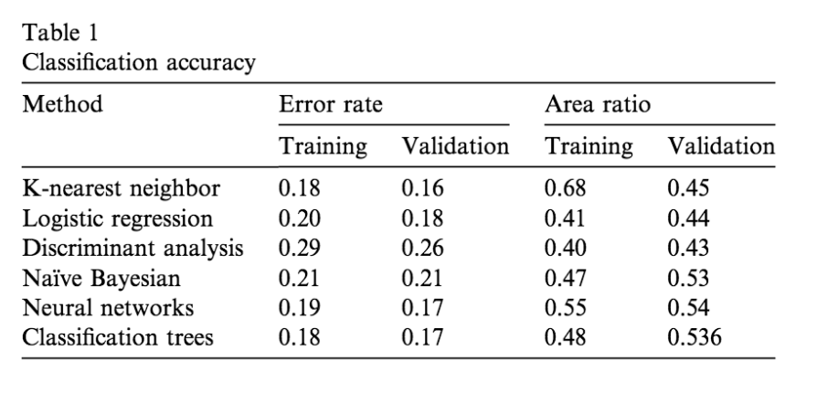

## Cleaning

### Formatting as .csv

The first thing we need to do is to create a `.csv` out of the original `.xls` file type found on UCI Machine Learning [Repository](https://archive.ics.uci.edu/ml/datasets/default+of+credit+card+clients).

The file is formatted with two headers, so we’ll be sure to skip the first one:

```r
library(here)
library(tidyverse)

d <- readxl::read_xls(here("data", "default of credit card clients.xls"), skip = 1)
d %>%
  rename(default = `default payment next month`) %>%
  write_csv(here("data", "defaults.csv"))
```

This makes it more portable between systems, especially if we want to read it into Python to use Keras for deep learning.

### Tidying

Let’s take a look at our data:

```r
library(here)
library(tidyverse)
library(recipes)

d <- read_csv(here("data", "defaults.csv"))
d <- d %>%
  select(-ID) %>%
  select(default, everything())
```

```r
glimpse(d)
```

```
## Observations: 30,000
## Variables: 24
## $ default   <int> 1, 1, 0, 0, 0, 0, 0, 0, 0, 0, 0, 0, 0, 1, 0, 0, 1, 0...
## $ LIMIT_BAL <dbl> 20000, 120000, 90000, 50000, 50000, 50000, 500000, 1...
## $ SEX       <int> 2, 2, 2, 2, 1, 1, 1, 2, 2, 1, 2, 2, 2, 1, 1, 2, 1, 1...
## $ EDUCATION <int> 2, 2, 2, 2, 2, 1, 1, 2, 3, 3, 3, 1, 2, 2, 1, 3, 1, 1...
## $ MARRIAGE  <int> 1, 2, 2, 1, 1, 2, 2, 2, 1, 2, 2, 2, 2, 2, 2, 3, 2, 1...
## $ AGE       <int> 24, 26, 34, 37, 57, 37, 29, 23, 28, 35, 34, 51, 41, ...
## $ PAY_0     <int> 2, -1, 0, 0, -1, 0, 0, 0, 0, -2, 0, -1, -1, 1, 0, 1,...
## $ PAY_2     <int> 2, 2, 0, 0, 0, 0, 0, -1, 0, -2, 0, -1, 0, 2, 0, 2, 0...
## $ PAY_3     <int> -1, 0, 0, 0, -1, 0, 0, -1, 2, -2, 2, -1, -1, 2, 0, 0...
## $ PAY_4     <int> -1, 0, 0, 0, 0, 0, 0, 0, 0, -2, 0, -1, -1, 0, 0, 0, ...
## $ PAY_5     <int> -2, 0, 0, 0, 0, 0, 0, 0, 0, -1, 0, -1, -1, 0, 0, 0, ...
## $ PAY_6     <int> -2, 2, 0, 0, 0, 0, 0, -1, 0, -1, -1, 2, -1, 2, 0, 0,...
## $ BILL_AMT1 <dbl> 3913, 2682, 29239, 46990, 8617, 64400, 367965, 11876...
## $ BILL_AMT2 <dbl> 3102, 1725, 14027, 48233, 5670, 57069, 412023, 380, ...
## $ BILL_AMT3 <dbl> 689, 2682, 13559, 49291, 35835, 57608, 445007, 601, ...
## $ BILL_AMT4 <dbl> 0, 3272, 14331, 28314, 20940, 19394, 542653, 221, 12...
## $ BILL_AMT5 <dbl> 0, 3455, 14948, 28959, 19146, 19619, 483003, -159, 1...
## $ BILL_AMT6 <dbl> 0, 3261, 15549, 29547, 19131, 20024, 473944, 567, 37...
## $ PAY_AMT1  <dbl> 0, 0, 1518, 2000, 2000, 2500, 55000, 380, 3329, 0, 2...
## $ PAY_AMT2  <dbl> 689, 1000, 1500, 2019, 36681, 1815, 40000, 601, 0, 0...
## $ PAY_AMT3  <dbl> 0, 1000, 1000, 1200, 10000, 657, 38000, 0, 432, 0, 5...
## $ PAY_AMT4  <dbl> 0, 1000, 1000, 1100, 9000, 1000, 20239, 581, 1000, 1...
## $ PAY_AMT5  <dbl> 0, 0, 1000, 1069, 689, 1000, 13750, 1687, 1000, 1122...
## $ PAY_AMT6  <dbl> 0, 2000, 5000, 1000, 679, 800, 13770, 1542, 1000, 0,...
```

```r
d %>%
  select_if(~any(is.na(.)))
```

```
## # A tibble: 30,000 x 0
```

The data looks pretty clean. All numerics without any NAs.

Next, we’ll split the data into a training and test set, since that is how the paper evaluated their models. The paper doesn’t specify the split percent, so we will use 33%. However, the outcomes are very unbalanced:

```r
d %>%
  group_by(default) %>%
  summarise(count = n())
```

```
## # A tibble: 2 x 2
##   default count
##     <int> <int>
## 1       0 23364
## 2       1  6636
```

The paper explicitly says it created the validation set randomly, so we will avoid using stratified sampling.

```r
library(rsample)
default_splits <- initial_split(d, prop = 2/3)
```

Next, we’ll use the `recipes` package to process our data. Some of the columns in the dataset are actually categorical variables encoded as integers. To be consistent between Python and R methods which may or may not accept categorical features, I will use recipes to dummy encode as necessary.

```r
default_rec <- recipe(default ~ ., training(default_splits)) %>%
  step_num2factor(SEX, EDUCATION, MARRIAGE) %>%
  step_dummy(SEX, EDUCATION, MARRIAGE) %>%
  prep(training(default_splits))
```

Lastly, we’ll also standardize the data set, a standard technique used in some of the study’s methods such as kNN and neural networks. The study does not say whether or not this sort of data pre-processing was used, so we will include it in our testing to see whether it impacts our results.

Also important: we’ll use the training data to calculate the mean and standard deviation, so our testing data doesn’t leak into our training.

```r
default_std_rec <- recipe(default ~ ., training(default_splits)) %>%
  step_center(all_predictors(), -SEX, -EDUCATION, -MARRIAGE) %>%
  step_scale(all_predictors(), -SEX, -EDUCATION, -MARRIAGE) %>%
  step_num2factor(SEX, EDUCATION, MARRIAGE) %>%
  step_dummy(SEX, EDUCATION, MARRIAGE) %>%
  prep(training(default_splits))
```

Then we will save the data as a `.csv` for future training.

```r
bake(default_rec, training(default_splits)) %>%
  write_csv(here("data", "train.csv"))

bake(default_rec, testing(default_splits)) %>%
  write_csv(here("data", "test.csv"))

bake(default_std_rec, training(default_splits)) %>%
  write_csv(here("data", "s-train.csv"))

bake(default_std_rec, testing(default_splits)) %>%
  write_csv(here("data", "s-test.csv"))
```

```r
glimpse(read_csv(here("data", "train.csv")))
```

```
## Observations: 20,000
## Variables: 31
## $ default      <int> 1, 1, 0, 0, 0, 0, 0, 0, 1, 0, 1, 0, 0, 0, 0, 1, 0...
## $ LIMIT_BAL    <dbl> 20000, 120000, 90000, 50000, 50000, 500000, 20000...
## $ AGE          <int> 24, 26, 34, 37, 37, 29, 34, 41, 30, 23, 24, 49, 4...
## $ PAY_0        <int> 2, -1, 0, 0, 0, 0, 0, -1, 1, 1, 0, 0, 1, 1, 0, -2...
## $ PAY_2        <int> 2, 2, 0, 0, 0, 0, 0, 0, 2, 2, 0, 0, -2, -2, 0, -2...
## $ PAY_3        <int> -1, 0, 0, 0, 0, 0, 2, -1, 2, 0, 2, 0, -2, -2, 0, ...
## $ PAY_4        <int> -1, 0, 0, 0, 0, 0, 0, -1, 0, 0, 2, -1, -2, -2, 0,...
## $ PAY_5        <int> -2, 0, 0, 0, 0, 0, 0, -1, 0, 0, 2, -1, -2, -2, 0,...
## $ PAY_6        <int> -2, 2, 0, 0, 0, 0, -1, -1, 2, 0, 2, -1, -2, -2, -...
## $ BILL_AMT1    <dbl> 3913, 2682, 29239, 46990, 64400, 367965, 11073, 1...
## $ BILL_AMT2    <dbl> 3102, 1725, 14027, 48233, 57069, 412023, 9787, 65...
## $ BILL_AMT3    <dbl> 689, 2682, 13559, 49291, 57608, 445007, 5535, 650...
## $ BILL_AMT4    <dbl> 0, 3272, 14331, 28314, 19394, 542653, 2513, 6500,...
```

[output cut: 18 more lines]

```r
glimpse(read_csv(here("data", "s-train.csv")))
```

```
## Observations: 20,000
## Variables: 31
## $ default      <int> 1, 1, 0, 0, 0, 0, 0, 0, 1, 0, 1, 0, 0, 0, 0, 1, 0...
## $ LIMIT_BAL    <dbl> -1.13711060, -0.36645924, -0.59765465, -0.9059151...
## $ AGE          <dbl> -1.2417420, -1.0244586, -0.1553250, 0.1706001, 0....
## $ PAY_0        <dbl> 1.81021178, -0.87509756, 0.02000555, 0.02000555, ...
## $ PAY_2        <dbl> 1.7990745, 1.7990745, 0.1173821, 0.1173821, 0.117...
## $ PAY_3        <dbl> -0.7013392, 0.1409079, 0.1409079, 0.1409079, 0.14...
## $ PAY_4        <dbl> -0.6692800, 0.1906455, 0.1906455, 0.1906455, 0.19...
## $ PAY_5        <dbl> -1.5322418, 0.2354066, 0.2354066, 0.2354066, 0.23...
## $ PAY_6        <dbl> -1.4866861, 1.9957279, 0.2545209, 0.2545209, 0.25...
## $ BILL_AMT1    <dbl> -0.643205266, -0.660056573, -0.296514593, -0.0535...
## $ BILL_AMT2    <dbl> -0.64727769, -0.66671019, -0.49310188, -0.0103798...
## $ BILL_AMT3    <dbl> -0.66799779, -0.63916247, -0.48179080, 0.03519038...
## $ BILL_AMT4    <dbl> -0.6722309, -0.6212272, -0.4488403, -0.2308742, -...
```

[output cut: 18 more lines]